# STSCI 4630 - Spring 2019 - HW3

Da (Harry) Lu, dl947

Due Tuesday, Feb/19/2019

# Question 1

> [15 points] Run lines 1 to 5. Adapt lines 6 to 9 to fit a location-scale Student’s t-distribution for the returns from Goldman Sachs (GS). Submit your output.

```r
#install.packages("MASS")
library(MASS)
fit=fitdistr(Returns$GS,"t")
fit
```

```
##         m              s              df
##   0.0005273569   0.0133452040   2.7340473894
##  (0.0003051133) (0.0003283650) (0.1609371218)
```

> 1. What is the maximum likelihood estimate of the degrees of freedom?

```r
fit$estimate[3]
```

```
##       df
## 2.734047
```

> 2. What is the standard error for the scale parameter?

```r
fit$sd[2]
```

```
##           s
## 0.000328365
```

> 3. Test the null hypothesis that the mean of the returns is 0 against the alternative hypothesis that the mean exceeds 0. Use the 5% significance level for your test. Would you conclude that the mean is positive?

$$Y=a+bT$$

where $a$ is the value of $\text{m}$ and $b$ is the value of $\text{s}$, $\nu$ is the value of $\text{df}$

$$\text{E}(Y)=a$$

$$\text{Var}(Y)=b^2\cdot\frac{\nu}{\nu-2}$$

In this testing, $\mu=0$

We use $\frac{a-\mu}{b\cdot\sqrt{\frac{\nu}{\nu-2}}}$ as the test statistic

```r
a=fit$estimate[[1]]
b=fit$estimate[[2]]
nu=fit$estimate[[3]]
t=(a-0)/(b*sqrt(nu/(nu-2)))
t
```

```
## [1] 0.02047569
```

```r
t<1.645
```

```
## [1] TRUE
```

# Question 2

> [15 points] Adapt and run lines 10 to 21 to fit the standardized Student’s t-distribution to the returns for Goldman Sachs (GS) by maximum likelihood. Submit your output.

```r
#install.packages("fGarch")
library(fGarch)
ret=Returns$GS
loglikstt=function(beta){sum(-dstd(ret,mean=beta[1],sd=beta[2],nu=beta[3],log=TRUE))}
start=c(mean(ret),sd(ret),5)
fitstt=optim(start,loglikstt,hessian=TRUE,method="L-BFGS-B",control=list(parscale=c(1e-4,1e-2,1)),lower=c(-1,0.001,1))
eststt=fitstt$par
sestt=sqrt(diag(solve(fitstt$hessian)))
parameter=c("mean","sd","nu")
rbind(parameter,round(eststt,7),round(sestt,7))
```

```
##           [,1]        [,2]        [,3]
## parameter "mean"      "sd"        "nu"
##           "0.0005306" "0.0266574" "2.6507656"
##           "0.0003036" "0.001946"  "0.1487207"
```

> 1. What is the maximum likelihood estimate of the degrees of freedom?

```r
round(eststt,7)[3]
```

```
## [1] 2.650766
```

> 2. Observe that the maximum likelihood estimate of the standard deviation is different from the maximum likelihood estimate of the scale parameter in Question 1. Are these results inconsistent? Justify your answer.

The distribution used in Question 1 is location-scale t-distribution, and the distribution used in Question 2 is standardized t-distribution. Because those two distributions are different, we cannot say the results are inconsistent only based on the different outcomes.

# Question 3

> [15 points] Recall that the F-S skewed Student’s t-density is right-skewed if $\xi>1$ and is left-skewed if $\xi<1$.

```r
x=seq(from=-4,to=4,length=500)
normdensity=dnorm(x,mean=0,sd=1)
sttdensity=dstd(x,mean=0,sd=1,nu=3)
skewtdensity=dsstd(x,mean=0,sd=1,nu=3,xi=2.5)
y=max(c(normdensity,sttdensity,skewtdensity))
```

> 1. By adapting and running lines 22 to 33, create a plot that compares three densities: the standard normal density; the standardized Student’s t-density with mean 0, standard deviation 1, and degrees of freedom 3; and the F-S skewed Student’s t density with mean 0, standard deviation 1, degrees of freedom 3, and skewness parameter $\xi=2.5$. Submit your plot.

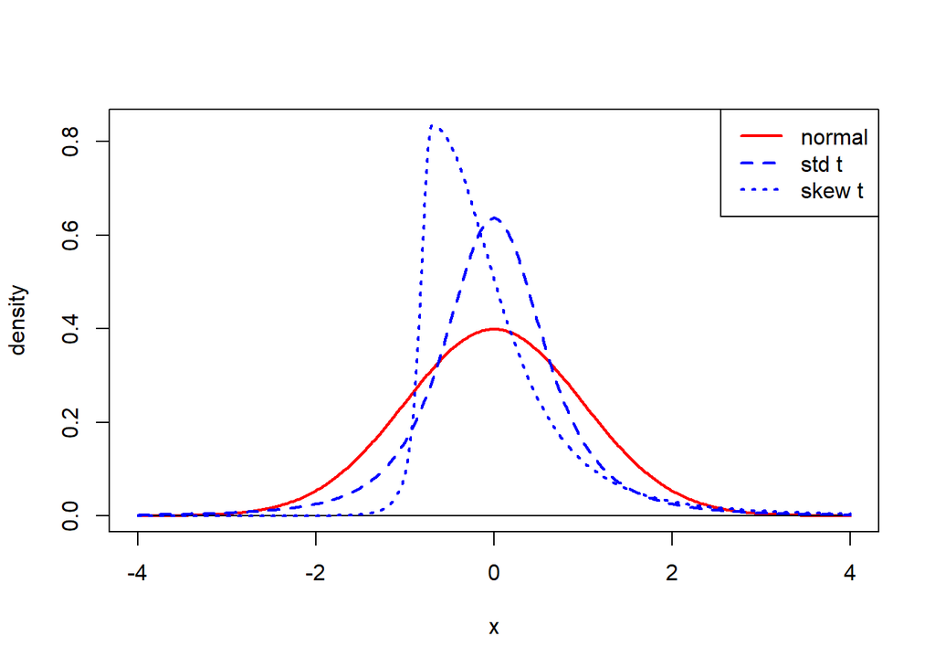

```r
plot(x, normdensity,type="l",lwd=2,lty=1,col="red",ylim=c(0,y),ylab="density")
lines(c(-4,4),c(0,0),lwd=1)
lines(x,sttdensity,type="l",lwd=2,col="blue",lty=2)
lines(x,skewtdensity,type="l",lwd=2,col="blue",lty=3)
legend("topright",y,legend=c("normal",paste("std t"),paste("skew t")),lty=c(1,2,3),lwd=c(2,2,2),col=c("red","blue","blue"),cex=1)
```

> 2. In your plot from Part i), is the F-S skewed Student’s t-density skewed to the right or skewed to the left?

The F-S skewed Student’s t-density is skewed to the right.

> 3. Repeat Part i) using skewness parameter $\xi=\frac{1}{2.5}$. Submit your plot.

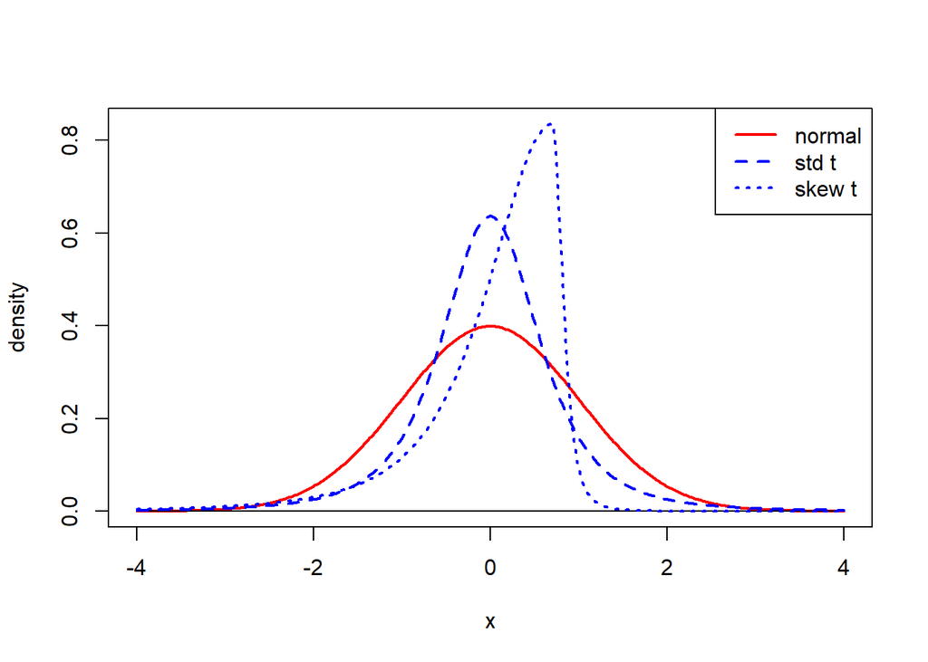

```r
skewtdensity2=dsstd(x,mean=0,sd=1,nu=3,xi=1/2.5)
y2=max(c(normdensity,sttdensity,skewtdensity2))
plot(x, normdensity,type="l",lwd=2,lty=1,col="red",ylim=c(0,y2),ylab="density")
lines(c(-4,4),c(0,0),lwd=1)
lines(x,sttdensity,type="l",lwd=2,col="blue",lty=2)
lines(x,skewtdensity2,type="l",lwd=2,col="blue",lty=3)
legend("topright",y2,legend=c("normal",paste("std t"),paste("skew t")),lty=c(1,2,3),lwd=c(2,2,2),col=c("red","blue","blue"),cex=1)
```

> 4. In your plot from Part iii), is the F-S skewed Student’s t-density skewed to the right or skewed to the left?

The F-S skewed Student’s t-density is skewed to the left.

# Question 4

> [15 points] By adapting and running lines 34 to 43, fit the F-S skewed Student’s tdistribution to the returns for Goldman Sachs (GS) by the method of maximum likelihood. Submit your output.

```r
x=Returns$GS
loglikskt=function(beta){sum(-dsstd(x,mean=beta[1],sd=beta[2],nu=beta[3],xi=beta[4],log=TRUE))}
start=c(mean(x),sd(x),5,1)
fitskt=optim(start,loglikskt,hessian=TRUE,method="L-BFGS-B",control=list(parscale=c(1e-4,1e-3,1,1)),lower=c(-0.1,0.01,1.8,0.001))
estskt=fitskt$par
seskt=sqrt(diag(solve(fitskt$hessian)))
parameter=c("mean","sd","nu","xi")
rbind(parameter,round(estskt,7),round(seskt,7))
```

```
##           [,1]        [,2]        [,3]        [,4]
## parameter "mean"      "sd"        "nu"        "xi"
##           "0.0002299" "0.0266256" "2.6542137" "0.972674"
##           "0.0004155" "0.0019335" "0.148922"  "0.0233196"
```

> 1. What is the maximum likelihood estimate $\hat\xi$ of $\xi$? Does this estimate suggest that the returns for Goldman Sachs (GS) are skewed to the right or skewed to the left?

```r
round(estskt,7)[4]
```

```
## [1] 0.972674
```

Since the estimate is less than 1, the returns are skewed to the left.

> 2. What is the standard error of $\hat\xi$?

```r
round(seskt,7)[4]
```

```
## [1] 0.0233196
```

> 3. Test the null hypothesis $H_0:\xi=1$ against the alternative hypothesis $H_A:\xi\neq1$ using the 5% level of significance. Is there evidence that the returns for Goldman Sachs (GS) are skewed?

```r
xi=round(estskt,7)[4]
mu=1
sd=round(seskt,7)[4]
t=(xi-mu)/sd
t
```

```
## [1] -1.171804
```

```r
t<1.96 & t>-1.96
```

```
## [1] TRUE
```

Test statistic $t$ is in the range of $(-1.96,1.96)$ so we do not reject Null Hypothesis

There is no evidence that the returns for GS are skewed

# Question 5

> [20 points] By adapting and running lines 44 to 48, estimate the linear regression of the returns of Goldman Sachs (GS) on the returns of the S&P 500 index (SP500) by the method of least squares. Provide 95% confidence intervals. Submit your output.

```r
fitLSE=lm(Returns$GS~Returns$SP500)
fitLSE
```

```
##
## Call:
## lm(formula = Returns$GS ~ Returns$SP500)
##
## Coefficients:
##   (Intercept)  Returns$SP500
##    -8.568e-05      1.434e+00
```

```r
summary(fitLSE)
```

```
##
## Call:
## lm(formula = Returns$GS ~ Returns$SP500)
##
## Residuals:
##       Min        1Q    Median        3Q       Max
## -0.139437 -0.007101 -0.000145  0.006916  0.144971
##
## Coefficients:
##                 Estimate Std. Error t value Pr(>|t|)
## (Intercept)   -8.568e-05  2.997e-04  -0.286    0.775
## Returns$SP500  1.434e+00  2.413e-02  59.436   <2e-16 ***
## ---
## Signif. codes:  0 '***' 0.001 '**' 0.01 '*' 0.05 '.' 0.1 ' ' 1
##
## Residual standard error: 0.01621 on 2925 degrees of freedom
## Multiple R-squared:  0.547,  Adjusted R-squared:  0.5469
## F-statistic:  3533 on 1 and 2925 DF,  p-value: < 2.2e-16
```

```r
round(confint(fitLSE,level=0.95),7)
```

```
##                    2.5 %    97.5 %
## (Intercept)   -0.0006732 0.0005019
## Returns$SP500  1.3866921 1.4813073
```

```r
round(head(fitLSE$residuals),7)
```

```
##          1          2          3          4          5          6
## -0.0190801 -0.0003300  0.0007390  0.0068111  0.0130959 -0.0053528
```

> 1. What are the least squares estimates of $\alpha$ and $\beta$?

```r
fitLSE$coefficients[[1]]
```

```
## [1] -8.567738e-05
```

```r
fitLSE$coefficients[[2]]
```

```
## [1] 1.434
```

The LSE of $\alpha$ is -8.567738e-05 and the LSE of $\beta$ is 1.434.

> 2. What is the standard error of the estimate of $\beta$?

```r
summary(fitLSE)$coefficients[2,2]
```

```
## [1] 0.02412697
```

> 3. What is the 95% confidence interval for $\beta$?

```r
lower=summary(fitLSE)$coefficients[2,1]-1.96*summary(fitLSE)$coefficients[2,2]
upper=summary(fitLSE)$coefficients[2,1]+1.96*summary(fitLSE)$coefficients[2,2]
lower
```

```
## [1] 1.386711
```

```r
upper
```

```
## [1] 1.481289
```

The 95% confidence interval for $\beta$ is $(1.386711,1.481289)$.

> 4. Based on your confidence interval in Part iii), would you reject the null hypothesis $H_0:\beta=1$ in favor of the alternative hypothesis $H_A:\beta\neq1$ in a test of level 5%?

Because 1 is not in the range of $(1.386711,1.481289)$ so we reject the Null Hypothesis.

> 22. What is the estimate of $\sigma_{\epsilon}$?

```r
summary(fitLSE)$sigma
```

```
## [1] 0.0162097
```

# Question 6

> [20 points] By adapting and running lines 49 to 63, use maximum likelihood to estimate the linear regression of the returns of Goldman Sachs (GS) on the returns of the S&P 500 index (SP500) under the assumption that the model disturbances have the standardized Student’s t-distribuion. Provide 95% confidence intervals. Submit your output.

```r
y=Returns$GS
x=Returns$SP500
fitLSE=lm(y~x)
loglik=function(beta){sum(-dstd(y,mean=beta[1]+beta[2]*x,sd=beta[3],nu=beta[4],log=TRUE))}
start=c(as.numeric(fitLSE$coefficient),sd(fitLSE$residuals),5)
fit=optim(start,loglik,hessian=TRUE,method="L-BFGS-B",control=list(parscale=c(1e-4,1,1e-3,1)),lower=c(-10,0.001,0.001,1))
mle=fit$par
se=sqrt(diag(solve(fit$hessian)))
lowerCL=round(mle+qnorm(0.025)*se,7)
upperCL=round(mle+qnorm(0.975)*se,7)
parameter=c("alpha","beta","sd","nu")
rbind(parameter,round(mle,7),round(se,7))
```

```
##           [,1]         [,2]        [,3]        [,4]
## parameter "alpha"      "beta"      "sd"        "nu"
##           "-0.0003151" "1.3678901" "0.0180398" "2.6336112"
##           "0.0002044"  "0.0222406" "0.0012963" "0.1405194"
```

```r
cbind(parameter,lowerCL,upperCL)
```

```
##      parameter lowerCL      upperCL
## [1,] "alpha"   "-0.0007156" "8.54e-05"
## [2,] "beta"    "1.3242993"  "1.4114809"
## [3,] "sd"      "0.0154991"  "0.0205805"
## [4,] "nu"      "2.3581982"  "2.9090242"
```

> 1. What are the maximum likelihood estimates of $\alpha$ and $\beta$?

```r
round(mle,7)[1]
```

```
## [1] -0.0003151
```

```r
round(mle,7)[2]
```

```
## [1] 1.36789
```

The maximum likelihood estimates of $\alpha$ and $\beta$ are -0.0003151 and 1.36789.

> 2. What is the standard error of the estimate of $\beta$?

```r
round(se,7)[2]
```

```
## [1] 0.0222406
```

> 3. What is the 95% confidence interval for $\beta$?

```r
lower=lowerCL[2]
upper=upperCL[2]
lower
```

```
## [1] 1.324299
```

```r
upper
```

```
## [1] 1.411481
```

The 95% confidence interval for $\beta$ is $(1.324299,1.411481)$.

> 22. What is the estimate of $\sigma_{\epsilon}$?

```r
round(mle,7)[3]
```

```
## [1] 0.0180398
```